# CMEnt Analysis of AML 450K Methylation Data

Biological interpretation of GSE63409

CMEnt Package

2026-06-10

# Contents

## 1 Introduction

This vignette analyzes GSE63409, an Illumina 450K methylation dataset from acute myeloid leukemia (AML). The dataset contains 15 AML patients represented by leukemia stem and blast cell samples, and normal hematopoietic stem and progenitor cell controls from healthy bone marrow.

The original study, Hu et al. 2019 ([doi:10.21037/atm.2019.11.122](https://dx.doi.org/10.21037/atm.2019.11.122)), used GSE63409 together with an expression dataset to identify AML-relevant methylation/expression signals, immune and differentiation pathways, and candidate prognostic genes. Because this dataset does not contain a region-level ground truth, the notebook focuses on biological interpretation of CMEnt regions rather than comparisons with other DMR callers.

- CMEnt DMR size, promoter/gene-body effect size, and CpG context
- AML marker and pathway DMR signals
- GO and KEGG enrichment of CMEnt DMRs
- Candidate gene-overlapping loci for follow-up biological interpretation

## 2 Setup and Dependencies

```r
try(devtools::load_all(), silent = TRUE)
suppressPackageStartupMessages({
    try(library(CMEnt), silent = TRUE)
    library(minfi)
    library(data.table)
    library(ggplot2)
    library(dplyr)
    library(GenomicRanges)
})

getBenchmarkFile <- function(filename) {
    benchmark_file <- ""
    folder <- "microarray450k"
    if (getwd() == "notebooks") {
        benchmark_file <- file.path("cached_results", folder, filename)
    } else if ("NAMESPACE" %in% dir()) {
        benchmark_file <- file.path("notebooks", "cached_results", folder, filename)
    } else {
        benchmark_file <- file.path("cached_results", folder, filename)
    }
    dir.create(dirname(benchmark_file), showWarnings = FALSE, recursive = TRUE)
    benchmark_file
}

split_ids <- function(x) {
    ids <- unlist(strsplit(stats::na.omit(as.character(x)), ","), use.names = FALSE)
    unique(ids[nzchar(ids)])
}

has_text <- function(x) {
    !is.na(x) & nzchar(as.character(x))
}

short_label <- function(x, width = 65L) {
    ifelse(nchar(x) > width, paste0(substr(x, 1L, width - 3L), "..."), x)
}
```

### 2.1 Install External Dependencies

```r
r <- getOption("repos")
if (is.null(r) || is.na(r["CRAN"]) || r["CRAN"] %in% c("@CRAN@", "")) {
  options(repos = c(CRAN = "https://cloud.r-project.org"))
}
if (!requireNamespace("BiocManager", quietly = TRUE)) {
    install.packages("BiocManager")
}

if (!requireNamespace("tidyr", quietly = TRUE)) {
    install.packages("tidyr")
}

if (!requireNamespace("scales", quietly = TRUE)) {
    install.packages("scales")
}

if (!requireNamespace("IlluminaHumanMethylation450kanno.ilmn12.hg19", quietly = TRUE)) {
    BiocManager::install("IlluminaHumanMethylation450kanno.ilmn12.hg19", update = FALSE, ask = FALSE)
}

if (!requireNamespace("TxDb.Hsapiens.UCSC.hg19.knownGene", quietly = TRUE)) {
    BiocManager::install("TxDb.Hsapiens.UCSC.hg19.knownGene", update = FALSE, ask = FALSE)
}

if (!requireNamespace("org.Hs.eg.db", quietly = TRUE)) {
    BiocManager::install("org.Hs.eg.db", update = FALSE, ask = FALSE)
}

if (!requireNamespace("missMethyl", quietly = TRUE)) {
    BiocManager::install("missMethyl", update = FALSE, ask = FALSE)
}
```

## 3 Load Data

Covariates are: - predictedSex: the sex predicted from methylation data, which can be a strong confounder in methylation analyses. - subject.id.ch1: the patient ID - source_name_ch1: the cell type

```r
covariates <- c("predictedSex", "subject.id.ch1", "source_name_ch1")
sample_group_col <- "subject.status.ch1"

beta <- getBenchmarkFile("GSE63409_beta_values.tsv.gz")
samplesheet <- getBenchmarkFile("GSE63409_samplesheet.tsv")

zenodo_base_url <- "https://zenodo.org/records/20592944/files/"
if (!file.exists(beta)) {
    curl::curl_download(
        url = paste0(zenodo_base_url, basename(beta), "?download=1"),
        destfile = beta
    )
}
if (!file.exists(samplesheet)) {
    curl::curl_download(
        url = paste0(zenodo_base_url, basename(samplesheet), "?download=1"),
        destfile = samplesheet
    )
}


pheno <- fread(samplesheet)
pheno[[sample_group_col]] <- factor(pheno[[sample_group_col]], levels = c("normal", "AML"))
pheno <- as.data.frame(pheno)
rownames(pheno) <- pheno$V1
array_type <- "450K"
genome <- "hg19"

beta_handler <- CMEnt::getBetaHandler(beta, array = array_type, genome = genome)
beta_mat <- as.matrix(beta_handler$getBeta())
locs <- beta_handler$getBetaLocs()
logit2 <- function(x) log2(x) - log2(1 - x)
mvalues <- logit2(beta_mat)
pheno$casecontrol <- pheno[[sample_group_col]] == "AML"
```

## 4 Find Differentially Methylated Positions

```r
dmps_file <- getBenchmarkFile("dmps.rds")
if (!file.exists(dmps_file)) {
    dmps <- CMEnt::findDMPsArray(
        beta_handler,
        pheno,
        sample_group_col = sample_group_col,
        id_col = "V1",
        covariates = covariates,
        array = array_type,
        genome = genome,
        njobs = max(1L, min(8L, parallel::detectCores(logical = TRUE) - 1L))
    )
    # sort DMPs by location
    rownames(dmps) <- dmps$site_id
    dmps <- dmps[rownames(locs), , drop = FALSE]
    dmps <- dmps[!is.na(dmps$pval), ]
    dmps$qval <- p.adjust(dmps$pval, method = "BH")

    case_idx <- which(pheno$casecontrol)
    ctrl_idx <- which(!pheno$casecontrol)
    dmps$delta_beta <- rowMeans(beta_mat[rownames(dmps), case_idx, drop = FALSE]) -
        rowMeans(beta_mat[rownames(dmps), ctrl_idx, drop = FALSE])

    dmps_gr <- makeGRangesFromDataFrame(
        data.frame(
            chr = locs$chr,
            start = locs$start,
            end = locs$end,
            pval = dmps$pval,
            qval = dmps$qval,
            stat = dmps$qval,
            delta_beta = dmps$delta_beta
        ),
        keep.extra.columns = TRUE
    )
    names(dmps_gr) <- rownames(dmps)
    saveRDS(dmps_gr, dmps_file)
} else {
    dmps_gr <- readRDS(dmps_file)
}
dmps <- as.data.frame(dmps_gr)
sig_dmps <- dmps[dmps$qval < 0.05 & abs(dmps$delta_beta) >= 0.05, ]
cat(sprintf("Found %d significant DMPs (FDR < 0.05, |delta beta| >= 0.05)\n", nrow(sig_dmps)))
```

Found 72556 significant DMPs (FDR < 0.05, |delta beta| >= 0.05)

## 5 Method 1: CMEnt

```r
cment_file <- getBenchmarkFile("dmrs.CMEnt.rds")
if (!file.exists(cment_file)) {
    cment_njobs <- max(1L, min(8L, parallel::detectCores(logical = TRUE) - 1L))
    options("CMEnt.verbose" = 1)
    options("CMEnt.njobs" = cment_njobs)
    cat(sprintf("CMEnt parallel jobs: %d\n", cment_njobs))
    cat(sprintf("parallel::detectCores(): %d\n", parallel::detectCores(logical = TRUE)))
    cat("Starting CMEnt::buildDMRs()...\n")
    flush.console()
    start_time <- Sys.time()
    dmrs_cment <- CMEnt::buildDMRs(
        beta = beta_handler,
        seeds = sig_dmps,
        pheno = pheno,
        sample_group_col = sample_group_col,
        casecontrol_col = "casecontrol",
        covariates = covariates,
        max_bridge_seeds_gaps  = 1,
        max_bridge_extension_gaps = 3,
        min_seeds = 2,
        min_sites = 3,
        ext_site_delta_beta = 0.2,
        max_lookup_dist = 1000,
        max_pval = 0.05,
        entanglement = "weak",
        njobs = cment_njobs,
        verbose = 1
    )
    end_time <- Sys.time()
    time_cment <- end_time - start_time
    saveRDS(list(dmrs = dmrs_cment, time = time_cment), cment_file)
} else {
    ret <- readRDS(cment_file)
    dmrs_cment <- ret$dmrs
    time_cment <- ret$time
}

cat(sprintf("CMEnt: Found %d DMRs in %d seconds\n", length(dmrs_cment), round(as.numeric(time_cment, units = "secs"))))
```

CMEnt: Found 8654 DMRs in 1049 seconds

## 6 CMEnt Region Summary

```r
if (!all(c("in_promoter_of", "in_gene_body_of", "delta_beta_promoter", "delta_beta_gene_body") %in% colnames(mcols(dmrs_cment))) &&
    requireNamespace("TxDb.Hsapiens.UCSC.hg19.knownGene", quietly = TRUE) &&
    requireNamespace("org.Hs.eg.db", quietly = TRUE)) {
    dmrs_cment <- CMEnt::annotateDMRsWithGenes(dmrs_cment, genome = genome)
}
for (gene_col in c("in_promoter_of", "in_gene_body_of")) {
    if (!gene_col %in% colnames(mcols(dmrs_cment))) {
        mcols(dmrs_cment)[[gene_col]] <- NA_character_
    }
}
for (delta_col in c("delta_beta_promoter", "delta_beta_gene_body")) {
    if (!delta_col %in% colnames(mcols(dmrs_cment))) {
        mcols(dmrs_cment)[[delta_col]] <- NA_real_
    }
}

dmr_delta_col <- if ("sites_delta_beta" %in% colnames(mcols(dmrs_cment))) {
    "sites_delta_beta"
} else {
    "delta_beta"
}
dmr_delta <- as.numeric(mcols(dmrs_cment)[[dmr_delta_col]])
dmr_direction <- ifelse(dmr_delta > 0, "Hypermethylated in AML", "Hypomethylated in AML")
dmr_summary <- data.frame(
    DMRs = length(dmrs_cment),
    Median_width_bp = median(width(dmrs_cment)),
    Mean_width_bp = round(mean(width(dmrs_cment)), 1),
    Total_coverage_bp = sum(width(dmrs_cment)),
    Median_delta_beta = round(median(dmr_delta, na.rm = TRUE), 4),
    Mean_abs_delta_beta = round(mean(abs(dmr_delta), na.rm = TRUE), 4),
    Hypermethylated_DMRs = sum(dmr_delta > 0, na.rm = TRUE),
    Hypomethylated_DMRs = sum(dmr_delta < 0, na.rm = TRUE)
)

knitr::kable(dmr_summary, caption = "CMEnt DMR summary for AML versus normal samples")
```

Table 1: CMEnt DMR summary for AML versus normal samples

| DMRs | Median_width_bp | Mean_width_bp | Total_coverage_bp | Median_delta_beta | Mean_abs_delta_beta | Hypermethylated_DMRs | Hypomethylated_DMRs |
| --- | --- | --- | --- | --- | --- | --- | --- |
| 8654 | 1315 | 1740.2 | 15059673 | 0.0082 | 0.1087 | 5034 | 3620 |

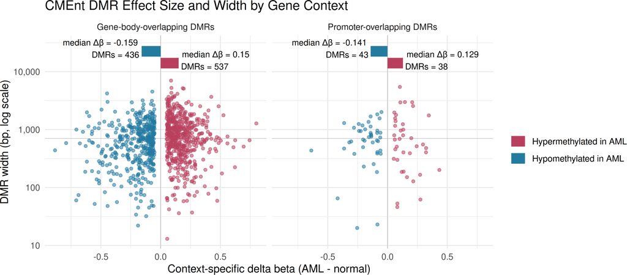

```r
dmrs_cment_only_promoter_or_gene_body <- dmrs_cment[!(is.finite(mcols(dmrs_cment)$delta_beta_promoter) & is.finite(mcols(dmrs_cment)$delta_beta_gene_body))]
dmr_effect_df <- bind_rows(
    data.frame(
        Region = "Promoter-overlapping DMRs",
        Width = width(dmrs_cment_only_promoter_or_gene_body),
        Delta_beta = as.numeric(mcols(dmrs_cment_only_promoter_or_gene_body)$delta_beta_promoter)
    ),
    data.frame(
        Region = "Gene-body-overlapping DMRs",
        Width = width(dmrs_cment_only_promoter_or_gene_body),
        Delta_beta = as.numeric(mcols(dmrs_cment_only_promoter_or_gene_body)$delta_beta_gene_body)
    )
) |>
    filter(is.finite(Delta_beta)) |>
    mutate(Direction = factor(
        ifelse(Delta_beta > 0, "Hypermethylated in AML", "Hypomethylated in AML"),
        levels = c("Hypermethylated in AML", "Hypomethylated in AML")
    ))

library(dplyr)
library(ggplot2)
library(scales)

ignore_abs_delta <- !is.finite(dmr_effect_df$Delta_beta) | abs(dmr_effect_df$Delta_beta) < 0.05
dmr_effect_df <- dmr_effect_df[!ignore_abs_delta,]
# Summary per Region and Direction
dmr_summary <- dmr_effect_df %>%
  group_by(Region, Direction) %>%
  summarise(
    median_delta_beta = median(Delta_beta, na.rm = TRUE),
    n_dmrs = n(),
    .groups = "drop"
  )

# Define two y-levels for the two summary bars
y_max <- max(dmr_effect_df$Width, na.rm = TRUE)

dmr_summary <- dmr_summary %>%
  mutate(
    bar_y = case_when(
      Direction == "Hypermethylated in AML" ~ y_max * 2.0,
      Direction == "Hypomethylated in AML"  ~ y_max * 3.2
    ),
    label_y = bar_y * 1.12
  )

# Expand y-range so the bars and labels fit
y_upper <- max(dmr_summary$label_y) * 1.15

ggplot(dmr_effect_df, aes(x = Delta_beta, y = Width, color = Direction)) +
  geom_hline(
    yintercept = median(dmr_effect_df$Width, na.rm = TRUE),
    linewidth = 0.2,
    color = "grey70"
  ) +
  geom_vline(xintercept = 0, linewidth = 0.2, color = "grey70") +
  geom_point(alpha = 0.55, size = 1.2) +

  # Separate horizontal bars for hypo and hyper
  geom_segment(
    data = dmr_summary,
    aes(
      x = 0,
      xend = median_delta_beta,
      y = bar_y,
      yend = bar_y,
      color = Direction
    ),
    inherit.aes = FALSE,
    linewidth = 5,
    lineend = "butt"
  ) +

  # Labels for each bar
  geom_text(
    data = dmr_summary,
    aes(
      x = median_delta_beta,
      y = label_y,
      label = paste0(
        "median Δβ = ", round(median_delta_beta, 3),
        "\nDMRs = ", n_dmrs
      )
    ),
    inherit.aes = FALSE,
    color = "black",
    size = 3,
    hjust = ifelse(dmr_summary$median_delta_beta >= 0, -0.05, 1.05)
  ) +

  facet_wrap(~Region, nrow = 1) +
  scale_y_log10(
    limits = c(min(dmr_effect_df$Width[dmr_effect_df$Width > 0], na.rm = TRUE), y_upper),
    labels = comma
  ) +
  scale_color_manual(
    values = c(
      "Hypermethylated in AML" = "#B8405E",
      "Hypomethylated in AML" = "#247BA0"
    )
  ) +
  coord_cartesian(clip = "off") +
  theme_minimal() +
  labs(
    title = "CMEnt DMR Effect Size and Width by Gene Context",
    x = "Context-specific delta beta (AML - normal)",
    y = "DMR width (bp, log scale)",
    color = ""
  )
```

## 7 CpG and Gene Context

```r
gene_context_df <- data.frame(
    Context = c("Promoter", "Gene body", "Promoter and gene body", "No annotated gene overlap"),
    DMRs = c(
        sum(has_text(mcols(dmrs_cment)$in_promoter_of)),
        sum(has_text(mcols(dmrs_cment)$in_gene_body_of)),
        sum(has_text(mcols(dmrs_cment)$in_promoter_of) & has_text(mcols(dmrs_cment)$in_gene_body_of)),
        sum(!has_text(mcols(dmrs_cment)$in_promoter_of) & !has_text(mcols(dmrs_cment)$in_gene_body_of))
    )
) |>
    mutate(Percentage = round(100 * DMRs / length(dmrs_cment), 1))

knitr::kable(gene_context_df, caption = "Gene context of CMEnt DMRs")
```

Table 2: Gene context of CMEnt DMRs

| Context | DMRs | Percentage |
| --- | --- | --- |
| Promoter | 5701 | 65.9 |
| Gene body | 7379 | 85.3 |
| Promoter and gene body | 5560 | 64.2 |
| No annotated gene overlap | 1134 | 13.1 |

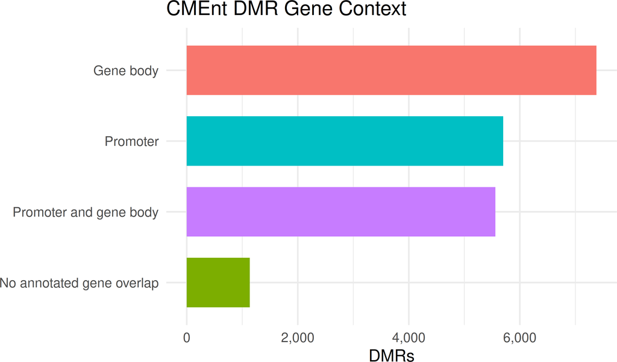

```r
ggplot(gene_context_df, aes(x = reorder(Context, DMRs), y = DMRs, fill = Context)) +
    geom_col(width = 0.7) +
    coord_flip() +
    scale_y_continuous(labels = scales::comma) +
    theme_minimal() +
    theme(legend.position = "none") +
    labs(title = "CMEnt DMR Gene Context", x = "", y = "DMRs")
```

```r
if (requireNamespace("IlluminaHumanMethylation450kanno.ilmn12.hg19", quietly = TRUE)) {
    library(IlluminaHumanMethylation450kanno.ilmn12.hg19)
    anno <- as.data.frame(minfi::getAnnotation(IlluminaHumanMethylation450kanno.ilmn12.hg19))
    anno$probe_id <- rownames(anno)

    dmr_site_ids <- split_ids(mcols(dmrs_cment)$sites)
    dmr_site_context <- anno[intersect(dmr_site_ids, rownames(anno)), c("probe_id", "Relation_to_Island")]
    dmp_site_context <- anno[intersect(rownames(sig_dmps), rownames(anno)), c("probe_id", "Relation_to_Island")]

    site_context_df <- bind_rows(
        dmp_site_context |> mutate(Source = "Significant DMPs"),
        dmr_site_context |> mutate(Source = "Sites inside CMEnt DMRs")
    ) |>
        count(Source, Relation_to_Island, name = "Sites") |>
        group_by(Source) |>
        mutate(Percentage = round(100 * Sites / sum(Sites), 1)) |>
        ungroup()

    knitr::kable(site_context_df, caption = "CpG island context of significant DMPs and sites inside CMEnt DMRs")
}
```

Table 3: CpG island context of significant DMPs and sites inside CMEnt DMRs

| Source | Relation_to_Island | Sites | Percentage |
| --- | --- | --- | --- |
| Significant DMPs | Island | 15527 | 21.4 |
| Significant DMPs | N_Shelf | 3821 | 5.3 |
| Significant DMPs | N_Shore | 12188 | 16.8 |
| Significant DMPs | OpenSea | 28474 | 39.2 |
| Significant DMPs | S_Shelf | 3289 | 4.5 |
| Significant DMPs | S_Shore | 9257 | 12.8 |
| Sites inside CMEnt DMRs | Island | 34457 | 44.3 |
| Sites inside CMEnt DMRs | N_Shelf | 2049 | 2.6 |
| Sites inside CMEnt DMRs | N_Shore | 15149 | 19.5 |
| Sites inside CMEnt DMRs | OpenSea | 13572 | 17.5 |
| Sites inside CMEnt DMRs | S_Shelf | 1403 | 1.8 |
| Sites inside CMEnt DMRs | S_Shore | 11136 | 14.3 |

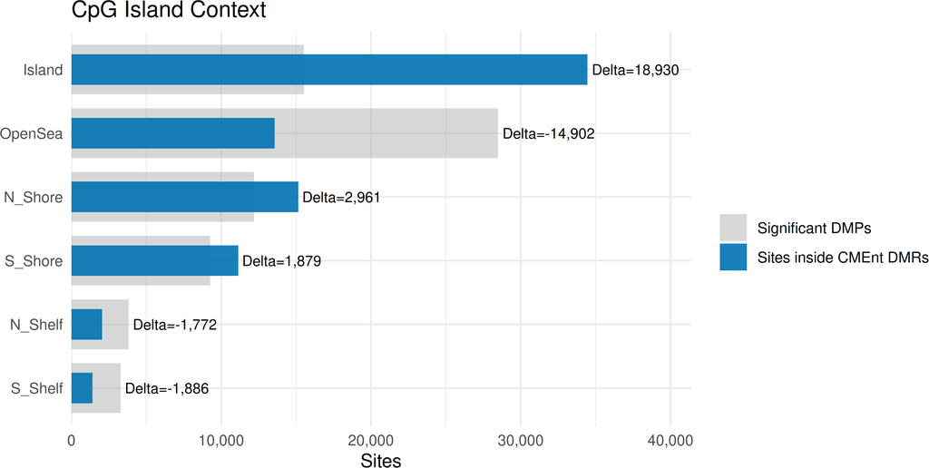

```r
if (exists("site_context_df")) {
    context_levels <- site_context_df |>
        group_by(Relation_to_Island) |>
        summarise(Max_sites = max(Sites), .groups = "drop") |>
        arrange(Max_sites) |>
        pull(Relation_to_Island)
    plot_context_df <- site_context_df |>
        mutate(
            Relation_to_Island = factor(Relation_to_Island, levels = context_levels),
            Source = factor(Source, levels = c("Significant DMPs", "Sites inside CMEnt DMRs"))
        )
    diff_df <- plot_context_df |>
        select(Source, Relation_to_Island, Sites) |>
        tidyr::pivot_wider(names_from = Source, values_from = Sites, values_fill = 0) |>
        mutate(
            Difference = `Sites inside CMEnt DMRs` - `Significant DMPs`,
            Label = paste0("Delta=", scales::comma(Difference)),
            Label_x = pmax(`Significant DMPs`, `Sites inside CMEnt DMRs`)
        )

    ggplot(plot_context_df, aes(x = Sites, y = Relation_to_Island, fill = Source)) +
        geom_col(data = filter(plot_context_df, Source == "Significant DMPs"), width = 0.78, alpha = 0.45) +
        geom_col(data = filter(plot_context_df, Source == "Sites inside CMEnt DMRs"), width = 0.48, alpha = 0.9) +
        geom_text(data = diff_df, aes(x = Label_x, y = Relation_to_Island, label = Label), inherit.aes = FALSE, hjust = -0.05, size = 3) +
        scale_x_continuous(labels = scales::comma, expand = expansion(mult = c(0, 0.2))) +
        scale_fill_manual(values = c("Significant DMPs" = "grey65", "Sites inside CMEnt DMRs" = "#0072B2")) +
        theme_minimal() +
        labs(title = "CpG Island Context", x = "Sites", y = "", fill = "")
}
```

## 8 AML Pathway and Marker Gene Scan

The table below is a targeted DMR scan of AML genetics, signaling, and hematopoietic/myeloid marker genes.

```r
gene_pattern <- function(gene) {
    paste0("(^|,)", gene, "($|,)")
}

dmr_gene_summary <- function(gene) {
    promoter_hits <- grepl(gene_pattern(gene), as.character(mcols(dmrs_cment)$in_promoter_of))
    body_hits <- grepl(gene_pattern(gene), as.character(mcols(dmrs_cment)$in_gene_body_of))
    dmr_hits <- promoter_hits | body_hits
    data.frame(
        Gene = gene,
        CMEnt_DMRs = sum(dmr_hits),
        Promoter_DMRs = sum(promoter_hits),
        Gene_body_DMRs = sum(body_hits),
        Mean_DMR_delta_beta = round(mean(dmr_delta[dmr_hits], na.rm = TRUE), 4)
    )
}

aml_prior_genes <- data.frame(
    Gene = c(
        "NPM1", "FLT3", "KIT", "RUNX1", "TP53", "TET2", "DNMT3A", "CXCR4", "NAT10",
        "JAK2", "STAT3", "STAT5A", "STAT5B", "HOXA9", "HOXA10",
        "CD34", "ITGAM", "SPI1", "CEBPA", "GATA2"
    ),
    Theme = c(
        rep("AML genetics/prognosis", 9),
        rep("JAK-STAT/HOXA signaling", 6),
        rep("Hematopoietic and myeloid differentiation", 5)
    )
)

prior_dmr_summary <- bind_rows(lapply(aml_prior_genes$Gene, dmr_gene_summary))

prior_gene_table <- aml_prior_genes |>
    left_join(prior_dmr_summary, by = "Gene") |>
    mutate(
        CMEnt_DMRs = tidyr::replace_na(CMEnt_DMRs, 0L),
        Methylation_signal = CMEnt_DMRs > 0
    ) |>
    arrange(desc(Methylation_signal), desc(CMEnt_DMRs), Gene)

knitr::kable(prior_gene_table, digits = 4, caption = "Targeted AML gene scan using CMEnt DMRs")
```

Table 4: Targeted AML gene scan using CMEnt DMRs

| Gene | Theme | CMEnt_DMRs | Promoter_DMRs | Gene_body_DMRs | Mean_DMR_delta_beta | Methylation_signal |
| --- | --- | --- | --- | --- | --- | --- |
| HOXA9 | JAK-STAT/HOXA signaling | 2 | 1 | 2 | -0.0007 | TRUE |
| CD34 | Hematopoietic and myeloid differentiation | 1 | 1 | 1 | 0.0699 | TRUE |
| GATA2 | Hematopoietic and myeloid differentiation | 1 | 1 | 1 | 0.0149 | TRUE |
| HOXA10 | JAK-STAT/HOXA signaling | 1 | 1 | 1 | 0.0706 | TRUE |
| RUNX1 | AML genetics/prognosis | 1 | 1 | 1 | -0.2875 | TRUE |
| STAT3 | JAK-STAT/HOXA signaling | 1 | 0 | 1 | -0.4134 | TRUE |
| CEBPA | Hematopoietic and myeloid differentiation | 0 | 0 | 0 | NaN | FALSE |
| CXCR4 | AML genetics/prognosis | 0 | 0 | 0 | NaN | FALSE |
| DNMT3A | AML genetics/prognosis | 0 | 0 | 0 | NaN | FALSE |
| FLT3 | AML genetics/prognosis | 0 | 0 | 0 | NaN | FALSE |
| ITGAM | Hematopoietic and myeloid differentiation | 0 | 0 | 0 | NaN | FALSE |
| JAK2 | JAK-STAT/HOXA signaling | 0 | 0 | 0 | NaN | FALSE |
| KIT | AML genetics/prognosis | 0 | 0 | 0 | NaN | FALSE |
| NAT10 | AML genetics/prognosis | 0 | 0 | 0 | NaN | FALSE |
| NPM1 | AML genetics/prognosis | 0 | 0 | 0 | NaN | FALSE |
| SPI1 | Hematopoietic and myeloid differentiation | 0 | 0 | 0 | NaN | FALSE |
| STAT5A | JAK-STAT/HOXA signaling | 0 | 0 | 0 | NaN | FALSE |
| STAT5B | JAK-STAT/HOXA signaling | 0 | 0 | 0 | NaN | FALSE |
| TET2 | AML genetics/prognosis | 0 | 0 | 0 | NaN | FALSE |
| TP53 | AML genetics/prognosis | 0 | 0 | 0 | NaN | FALSE |

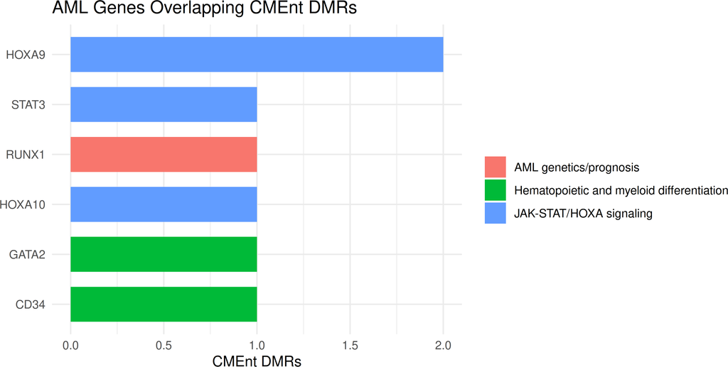

```r
prior_plot_df <- prior_gene_table |>
    filter(Methylation_signal) |>
    mutate(Gene = reorder(Gene, CMEnt_DMRs))

if (nrow(prior_plot_df) > 0) {
    ggplot(prior_plot_df, aes(x = Gene, y = CMEnt_DMRs, fill = Theme)) +
        geom_col(width = 0.7) +
        coord_flip() +
        theme_minimal() +
        labs(title = "AML Genes Overlapping CMEnt DMRs", x = "", y = "CMEnt DMRs", fill = "")
}
```

## 9 GO and KEGG Enrichment

`missMethyl` performs methylation-array-aware enrichment for CMEnt DMRs while correcting for probe-number bias across genes.

```r
aml_term_pattern <- paste(
    c(
        "acute myeloid", "leukemia", "leukaemia", "myeloid", "hematopoiet", "haematopoiet",
        "stem cell", "differentiation", "immune", "leukocyte", "lymphocyte", "granulocyte",
        "monocyte", "macrophage", "cytokine", "chemokine", "phagosome", "JAK", "STAT",
        "HOX", "FLT3", "NPM1", "DNA methylation", "apoptosis", "cell cycle",
        "transcriptional misregulation"
    ),
    collapse = "|"
)

normalize_missmethyl_result <- function(x, collection) {
    if (is.null(x) || nrow(x) == 0L) {
        return(NULL)
    }
    x <- as.data.frame(x)
    term_col <- intersect(c("Term", "TERM", "Description", "Pathway"), colnames(x))[1]
    fdr_col <- intersect(c("FDR", "adj.P.Val", "P.DE", "P.Value"), colnames(x))[1]
    p_col <- intersect(c("P.DE", "P.Value", "P.DE.weighted"), colnames(x))[1]
    de_col <- intersect(c("DE", "N_DE", "Count"), colnames(x))[1]
    n_col <- intersect(c("N", "Total", "Size"), colnames(x))[1]
    ont_col <- intersect(c("Ont", "Ontology", "Category"), colnames(x))[1]
    if (is.na(term_col) || is.na(fdr_col)) {
        return(NULL)
    }
    data.frame(
        Collection = collection,
        Term = as.character(x[[term_col]]),
        Ontology = if (!is.na(ont_col)) as.character(x[[ont_col]]) else collection,
        N = if (!is.na(n_col)) suppressWarnings(as.numeric(x[[n_col]])) else NA_real_,
        DE = if (!is.na(de_col)) suppressWarnings(as.numeric(x[[de_col]])) else NA_real_,
        PValue = if (!is.na(p_col)) suppressWarnings(as.numeric(x[[p_col]])) else NA_real_,
        FDR = suppressWarnings(as.numeric(x[[fdr_col]])),
        stringsAsFactors = FALSE
    )
}

missmethyl_long <- NULL
if (requireNamespace("missMethyl", quietly = TRUE) &&
    requireNamespace("IlluminaHumanMethylation450kanno.ilmn12.hg19", quietly = TRUE)) {
    library(IlluminaHumanMethylation450kanno.ilmn12.hg19)
    cached <- getBenchmarkFile("missmethyl_cment_enrichment_results.rds")
    if (file.exists(cached)) {
        missmethyl_long <- readRDS(cached)
    } else {
        missmethyl_long <- base::do.call(rbind, Filter(Negate(is.null), lapply(c("GO", "KEGG"), function(collection) {
            ret <- tryCatch(
                missMethyl::goregion(
                    regions = dmrs_cment,
                    all.cpg = rownames(locs),
                    collection = collection,
                    array.type = "450K",
                    plot.bias = FALSE,
                    prior.prob = TRUE
                ),
                error = function(e) {
                    warning(sprintf("missMethyl %s enrichment failed for CMEnt DMRs: %s", collection, e$message))
                    NULL
                }
            )
            normalize_missmethyl_result(ret, collection)
        })))
        saveRDS(missmethyl_long, cached)
    }
} else {
    cat("missMethyl or the 450K annotation package is required for GO/KEGG enrichment.\n")
}
```

```r
if (!is.null(missmethyl_long) && nrow(missmethyl_long) > 0L) {
    missmethyl_long <- missmethyl_long[is.finite(missmethyl_long$FDR), , drop = FALSE]
    missmethyl_long$NegLog10FDR <- -log10(pmax(missmethyl_long$FDR, .Machine$double.xmin))
    missmethyl_long$AML_Context <- ifelse(grepl(aml_term_pattern, missmethyl_long$Term, ignore.case = TRUE), "AML-context term", "Other top term")

    missmethyl_top <- missmethyl_long |>
        group_by(Collection) |>
        arrange(FDR, .by_group = TRUE) |>
        slice_head(n = 10) |>
        ungroup()
    missmethyl_top$Term_Label <- short_label(missmethyl_top$Term, 70)
    missmethyl_top$Term_Collection <- factor(
        paste(missmethyl_top$Term_Label, missmethyl_top$Collection, sep = "___"),
        levels = rev(unique(paste(missmethyl_top$Term_Label, missmethyl_top$Collection, sep = "___")))
    )

    knitr::kable(
        missmethyl_top |>
            dplyr::select(Collection, Ontology, Term, N, DE, PValue, FDR, AML_Context) |>
            arrange(Collection, FDR),
        digits = 3,
        row.names = FALSE,
        caption = "Top missMethyl GO/KEGG enrichments from CMEnt DMRs"
    )
}
```

Table 5: Top missMethyl GO/KEGG enrichments from CMEnt DMRs

| Collection | Ontology | Term | N | DE | PValue | FDR | AML_Context |
| --- | --- | --- | --- | --- | --- | --- | --- |
| GO | GO | cell periphery | 5528 | 2122 | 0 | 0.000 | Other top term |
| GO | GO | system development | 3248 | 1426 | 0 | 0.000 | Other top term |
| GO | GO | multicellular organismal process | 6251 | 2353 | 0 | 0.000 | Other top term |
| GO | GO | anatomical structure development | 4906 | 1970 | 0 | 0.000 | Other top term |
| GO | GO | multicellular organism development | 3760 | 1586 | 0 | 0.000 | Other top term |
| GO | GO | developmental process | 5445 | 2140 | 0 | 0.000 | Other top term |
| GO | GO | nervous system development | 2074 | 978 | 0 | 0.000 | Other top term |
| GO | GO | plasma membrane | 5086 | 1931 | 0 | 0.000 | Other top term |
| GO | GO | cell-cell signaling | 1146 | 546 | 0 | 0.000 | Other top term |
| GO | GO | gated channel activity | 298 | 183 | 0 | 0.000 | Other top term |
| KEGG | KEGG | Neuroactive ligand-receptor interaction | 341 | 180 | 0 | 0.000 | Other top term |
| KEGG | KEGG | Neuroactive ligand signaling | 192 | 120 | 0 | 0.000 | Other top term |
| KEGG | KEGG | Cadherin signaling | 392 | 185 | 0 | 0.000 | Other top term |
| KEGG | KEGG | Nicotine addiction | 36 | 30 | 0 | 0.000 | Other top term |
| KEGG | KEGG | Calcium signaling pathway | 238 | 129 | 0 | 0.000 | Other top term |
| KEGG | KEGG | Cell adhesion molecule (CAM) interaction | 144 | 77 | 0 | 0.000 | Other top term |
| KEGG | KEGG | Type I diabetes mellitus | 42 | 27 | 0 | 0.004 | Other top term |
| KEGG | KEGG | Hormone signaling | 209 | 93 | 0 | 0.007 | Other top term |
| KEGG | KEGG | Signaling pathways regulating pluripotency of stem cells | 138 | 74 | 0 | 0.007 | AML-context term |
| KEGG | KEGG | Morphine addiction | 88 | 52 | 0 | 0.007 | Other top term |

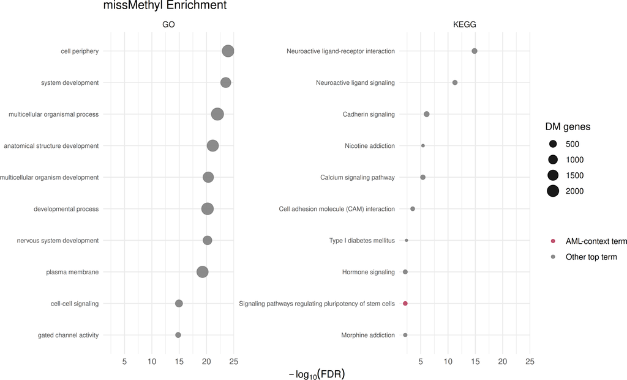

```r
if (!is.null(missmethyl_long) && nrow(missmethyl_long) > 0L) {
    ggplot(missmethyl_top, aes(x = NegLog10FDR, y = Term_Collection, size = DE, color = AML_Context)) +
        geom_point(alpha = 0.9) +
        facet_wrap(~Collection, scales = "free_y") +
        scale_y_discrete(labels = function(x) sub("___.*$", "", x)) +
        scale_color_manual(values = c("AML-context term" = "#B8405E", "Other top term" = "grey50")) +
        theme_minimal() +
        theme(axis.text.y = element_text(size = 7)) +
        labs(title = "missMethyl Enrichment", x = expression(-log[10]("FDR")), y = "", color = "", size = "DM genes")
} else {
    cat("missMethyl returned no enrichment results.\n")
}
```

```r
focused_terms <- if (!is.null(missmethyl_long) && nrow(missmethyl_long) > 0L) {
    missmethyl_long |>
        filter(grepl(aml_term_pattern, Term, ignore.case = TRUE)) |>
        group_by(Collection) |>
        arrange(FDR, .by_group = TRUE) |>
        slice_head(n = 8) |>
        ungroup()
} else {
    data.frame()
}

if (nrow(focused_terms) > 0L) {
    focused_terms$Term_Label <- short_label(focused_terms$Term, 62)
    focused_terms$Term_Collection <- factor(
        paste(focused_terms$Term_Label, focused_terms$Collection, sep = "___"),
        levels = rev(unique(paste(focused_terms$Term_Label, focused_terms$Collection, sep = "___")))
    )
    knitr::kable(
        focused_terms |>
            dplyr::select(Collection, Ontology, Term, N, DE, PValue, FDR) |>
            arrange(Collection, FDR),
        digits = 3,
        row.names = FALSE,
        caption = "Top AML-relevant GO/KEGG terms"
    )
}
```

Table 6: Top AML-relevant GO/KEGG terms

| Collection | Ontology | Term | N | DE | PValue | FDR |
| --- | --- | --- | --- | --- | --- | --- |
| GO | GO | cell differentiation | 3702 | 1479 | 0.000 | 0.000 |
| GO | GO | neuron differentiation | 1112 | 534 | 0.000 | 0.000 |
| GO | GO | positive regulation of cell differentiation | 738 | 334 | 0.000 | 0.000 |
| GO | GO | central nervous system neuron differentiation | 115 | 76 | 0.000 | 0.000 |
| GO | GO | regulation of cell differentiation | 1331 | 545 | 0.000 | 0.000 |
| GO | GO | muscle cell differentiation | 350 | 166 | 0.000 | 0.000 |
| GO | GO | striated muscle cell differentiation | 263 | 123 | 0.000 | 0.002 |
| GO | GO | regulation of neuron differentiation | 114 | 65 | 0.000 | 0.004 |
| KEGG | KEGG | Signaling pathways regulating pluripotency of stem cells | 138 | 74 | 0.000 | 0.007 |
| KEGG | KEGG | Autoimmune thyroid disease | 39 | 21 | 0.003 | 0.063 |
| KEGG | KEGG | Hematopoietic cell lineage | 90 | 37 | 0.013 | 0.138 |
| KEGG | KEGG | Cytokine-cytokine receptor interaction | 258 | 84 | 0.020 | 0.186 |
| KEGG | KEGG | Intestinal immune network for IgA production | 45 | 20 | 0.032 | 0.282 |
| KEGG | KEGG | Viral protein interaction with cytokine and cytokine receptor | 89 | 26 | 0.161 | 0.716 |
| KEGG | KEGG | Chemokine signaling pathway | 181 | 54 | 0.834 | 1.000 |
| KEGG | KEGG | Cell cycle | 153 | 22 | 1.000 | 1.000 |

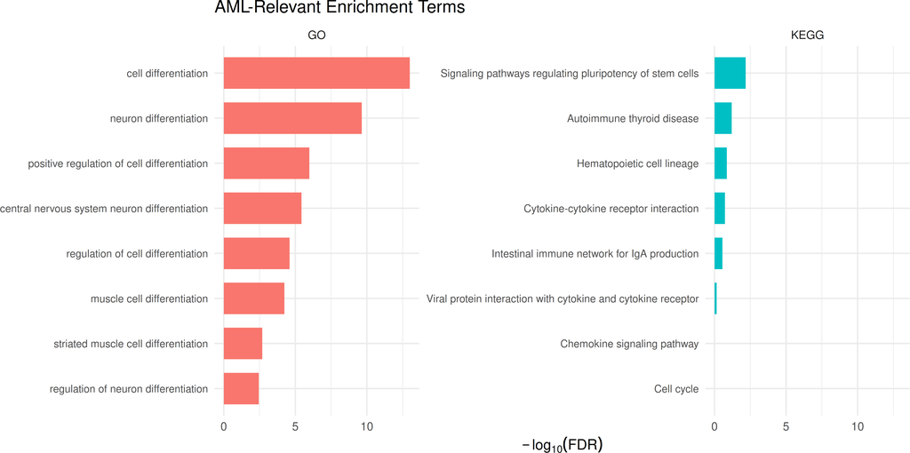

```r
if (nrow(focused_terms) > 0L) {
    ggplot(focused_terms, aes(x = -log10(pmax(FDR, .Machine$double.xmin)), y = Term_Collection, fill = Collection)) +
        geom_col(width = 0.7) +
        facet_wrap(~Collection, scales = "free_y") +
        scale_y_discrete(labels = function(x) sub("___.*$", "", x)) +
        theme_minimal() +
        theme(axis.text.y = element_text(size = 8), legend.position = "none") +
        labs(title = "AML-Relevant Enrichment Terms", x = expression(-log[10]("FDR")), y = "")
} else {
    cat("No missMethyl terms matched the AML-focused keyword set.\n")
}
```

## 10 Candidate CMEnt Gene Overlapping Loci

```r
dmr_table <- as.data.frame(dmrs_cment)
dmr_table$DMR <- paste0(dmr_table$seqnames, ":", dmr_table$start, "-", dmr_table$end)
dmr_table$delta_beta_for_ranking <- dmr_delta
dmr_table$abs_delta_beta <- abs(dmr_delta)
dmr_table$svm_score_for_ranking <- if ("score" %in% colnames(dmr_table)) dmr_table$score else 0
if (!"qval" %in% colnames(dmr_table)) {
    dmr_table$qval <- NA_real_
}
if (!"pval" %in% colnames(dmr_table)) {
    dmr_table$pval <- NA_real_
}
if (!"score" %in% colnames(dmr_table)) {
    dmr_table$score <- NA_real_
}

top_dmrs <- dmr_table |>
    filter(has_text(in_promoter_of) | has_text(in_gene_body_of)) |>
    arrange(desc(svm_score_for_ranking), qval, desc(abs_delta_beta)) |>
    select(
        DMR,
        width,
        score,
        qval,
        pval,
        delta_beta_for_ranking,
        any_of(c("delta_beta_promoter", "delta_beta_gene_body", "seeds_num", "sites_num", "in_promoter_of", "in_gene_body_of"))
    ) |>
    head(20)

knitr::kable(top_dmrs, digits = 4, caption = "Top 20 promoter or gene-body overlapping CMEnt DMRs ranked by score")
```

Table 7: Top 20 promoter or gene-body overlapping CMEnt DMRs ranked by score

|  | DMR | width | score | qval | pval | delta_beta_for_ranking | delta_beta_promoter | delta_beta_gene_body | seeds_num | sites_num | in_promoter_of | in_gene_body_of |
| --- | --- | --- | --- | --- | --- | --- | --- | --- | --- | --- | --- | --- |
| chr1:cg14278300-cg09554443 | chr1:167486978-167487762 | 785 | 0.6566 | 0e+00 | 0e+00 | -0.0627 | -0.3938 | -0.0627 | 2 | 5 | CD247 | CD247 |
| chr8:cg25247520-cg00780520 | chr8:128808017-128808554 | 538 | 0.6352 | 0e+00 | 0e+00 | -0.3510 | -0.3603 | -0.3395 | 3 | 3 | PVT1 | PVT1 |
| chr21:cg05126444-cg16704958 | chr21:38629859-38630728 | 870 | 0.6281 | 0e+00 | 0e+00 | -0.1452 | NA | -0.1452 | 2 | 5 | NA | VPS26C |
| chr17:cg09489844-cg10168457 | chr17:79880647-79882876 | 2230 | 0.6262 | 0e+00 | 0e+00 | -0.0552 | -0.0020 | -0.0020 | 3 | 10 | MAFG-AS1,MAFG,SIRT7,MILIP | MAFG-AS1,MAFG,MILIP |
| chr10:cg10770832-cg09622269 | chr10:76803270-76803925 | 656 | 0.6242 | 0e+00 | 0e+00 | 0.2904 | NA | 0.2755 | 5 | 5 | NA | DUSP29 |
| chr19:cg24291974-cg19417168 | chr19:4531638-4531961 | 324 | 0.6166 | 0e+00 | 0e+00 | -0.4472 | NA | -0.3740 | 4 | 4 | NA | PLIN5 |
| chr11:cg26512142-cg05898618 | chr11:2554198-2555576 | 1379 | 0.6147 | 0e+00 | 0e+00 | -0.0686 | NA | -0.0520 | 4 | 11 | NA | KCNQ1 |
| chr16:cg05673293-cg07605834 | chr16:71475279-71475926 | 648 | 0.6109 | 0e+00 | 0e+00 | 0.4046 | 0.0978 | 0.4250 | 4 | 5 | TLE7 | TLE7 |
| chr10:cg19007269-cg13564061 | chr10:105420501-105421480 | 980 | 0.6092 | 0e+00 | 0e+00 | -0.2460 | -0.3165 | -0.2708 | 4 | 6 | SH3PXD2A | SH3PXD2A |
| chr11:cg18431910-cg13228701 | chr11:78614239-78614522 | 284 | 0.6091 | 1e-04 | 1e-04 | 0.2831 | NA | 0.2831 | 2 | 3 | NA | TENM4 |
| chr7:cg01572810-cg16810272 | chr7:150901654-150902685 | 1032 | 0.6061 | 0e+00 | 0e+00 | 0.3312 | -0.0022 | 0.3526 | 2 | 3 | DRC11L | DRC11L |
| chr6:cg11805138-cg23457357 | chr6:31148332-31148748 | 417 | 0.6030 | 0e+00 | 0e+00 | -0.0579 | -0.0563 | -0.0563 | 11 | 15 | POU5F1 | PSORS1C3,POU5F1 |
| chr17:cg11252953-cg21465176 | chr17:80358829-80358876 | 48 | 0.5986 | 0e+00 | 0e+00 | -0.0269 | NA | -0.0269 | 2 | 3 | NA | OGFOD3 |
| chr2:cg03322446-cg24601559 | chr2:43327014-43328536 | 1523 | 0.5967 | 0e+00 | 0e+00 | 0.3097 | NA | 0.3041 | 6 | 7 | NA | LINC02580,LINC01819 |
| chr3:cg21463380-cg21526749 | chr3:187389127-187389513 | 387 | 0.5967 | 0e+00 | 0e+00 | -0.0854 | -0.0854 | NA | 2 | 3 | SST | NA |
| chr11:cg20244273-cg01607369 | chr11:7597349-7598673 | 1325 | 0.5955 | 0e+00 | 0e+00 | -0.2169 | -0.3501 | -0.1600 | 2 | 5 | PPFIBP2 | PPFIBP2 |
| chr17:cg26118142-cg16810621 | chr17:3289363-3290164 | 802 | 0.5938 | 0e+00 | 0e+00 | 0.1574 | 0.0763 | 0.0763 | 3 | 6 | OR3A2,OR1R1 | OR3A2,OR1R1 |
| chr11:cg10321236-cg03908908 | chr11:76849101-76849564 | 464 | 0.5938 | 0e+00 | 0e+00 | 0.2971 | 0.3106 | 0.3313 | 4 | 4 | MYO7A | MYO7A |
| chr15:cg21819984-cg08428878 | chr15:101084507-101085341 | 835 | 0.5930 | 0e+00 | 0e+00 | 0.2879 | 0.3293 | 0.3515 | 7 | 8 | CERS3 | CERS3 |
| chr1:cg16104450-cg06882058 | chr1:243645911-243646787 | 877 | 0.5923 | 0e+00 | 0e+00 | -0.1044 | NA | -0.1044 | 2 | 7 | NA | SDCCAG8 |

## 11 Top CMEnt DMR Visualization

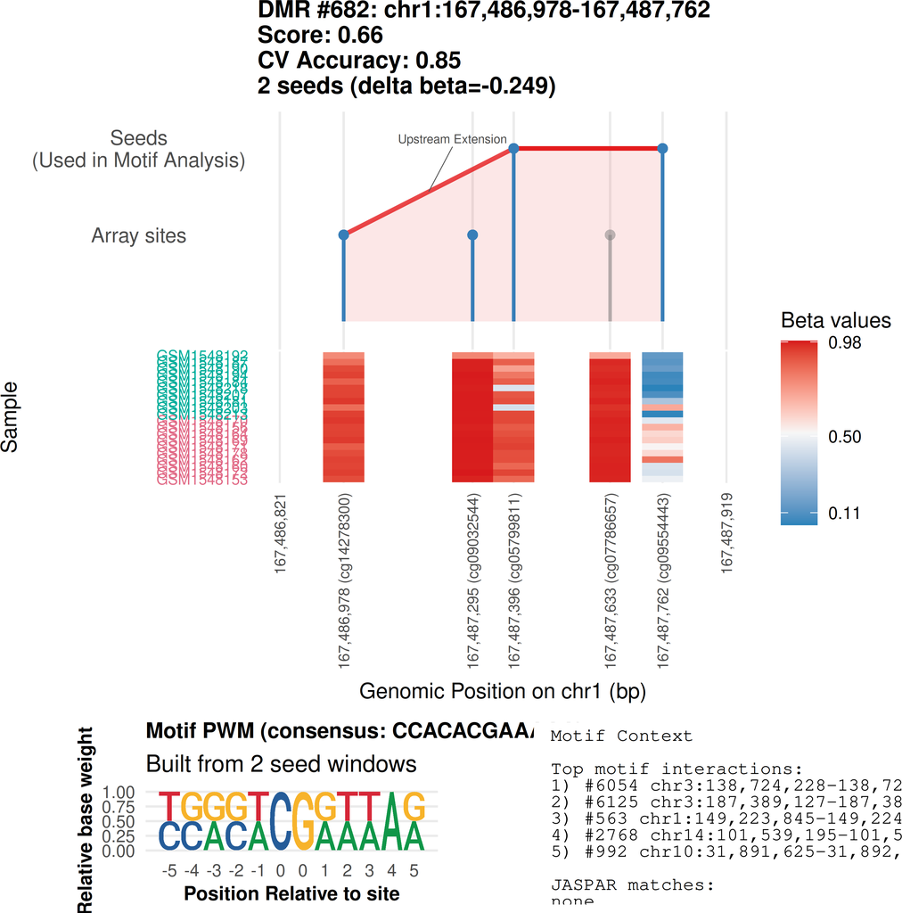

```r
CMEnt::plotDMRs(
    dmrs_cment,
    top_n = 1,
    score_by = "score",
    beta = beta_handler,
    pheno = pheno,
    sample_group_col = sample_group_col,
    genome = "hg19",
    array = array_type
)
```

## 12 CMEnt DMR Manhattan Plot

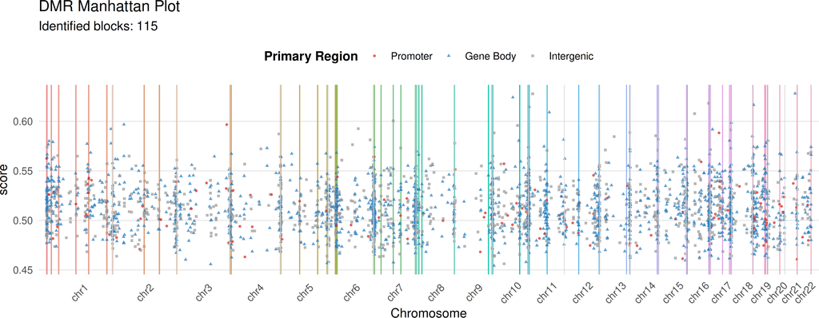

```r
CMEnt::plotDMRsManhattan(
    dmrs_cment,
    genome = "hg19")
```

## 13 CMEnt DMR Interaction Circos Visualization

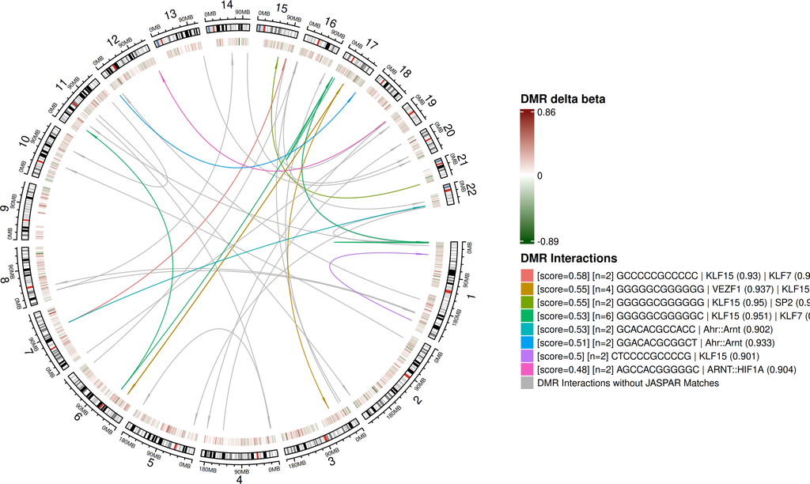

```r
CMEnt::plotDMRsCircos(
    dmrs_cment,
    genome = "hg19",
    array = array_type
)
```

R version 4.6.0 (2026-04-24) Platform: x86_64-pc-linux-gnu Running under: Ubuntu 24.04.4 LTS

Matrix products: default BLAS: /usr/lib/x86_64-linux-gnu/openblas-pthread/libblas.so.3 LAPACK: /usr/lib/x86_64-linux-gnu/openblas-pthread/libopenblasp-r0.3.26.so; LAPACK version 3.12.0

locale: [1] LC_CTYPE=C.UTF-8 LC_NUMERIC=C LC_TIME=C.UTF-8  
[4] LC_COLLATE=C.UTF-8 LC_MONETARY=C.UTF-8 LC_MESSAGES=C.UTF-8  
[7] LC_PAPER=C.UTF-8 LC_NAME=C LC_ADDRESS=C  
[10] LC_TELEPHONE=C LC_MEASUREMENT=C.UTF-8 LC_IDENTIFICATION=C

time zone: Europe/Brussels tzcode source: system (glibc)

attached base packages: [1] parallel stats4 stats graphics grDevices datasets utils  
[8] methods base

other attached packages: [1] IlluminaHumanMethylation450kanno.ilmn12.hg19_0.6.1 [2] scales_1.4.0  
[3] dplyr_1.2.1  
[4] ggplot2_4.0.3  
[5] data.table_1.18.4  
[6] minfi_1.58.0  
[7] bumphunter_1.54.0  
[8] locfit_1.5-9.12  
[9] iterators_1.0.14  
[10] foreach_1.5.2  
[11] Biostrings_2.80.1  
[12] XVector_0.52.0  
[13] SummarizedExperiment_1.42.0  
[14] Biobase_2.72.0  
[15] MatrixGenerics_1.24.0  
[16] matrixStats_1.5.0  
[17] GenomicRanges_1.64.0  
[18] Seqinfo_1.2.0  
[19] IRanges_2.46.0  
[20] S4Vectors_0.50.1  
[21] BiocGenerics_0.58.1  
[22] generics_0.1.4  
[23] CMEnt_0.99.0  
[24] testthat_3.3.2  
[25] BiocStyle_2.40.0

loaded via a namespace (and not attached): [1] splines_4.6.0 BiocIO_1.22.0  
[3] filelock_1.0.3 bitops_1.0-9  
[5] tibble_3.3.1 R.oo_1.27.1  
[7] preprocessCore_1.74.0 DirichletMultinomial_1.54.0 [9] XML_3.99-0.23 httr2_1.2.2  
[11] lifecycle_1.0.5 pwalign_1.8.0  
[13] doParallel_1.0.17 lattice_0.22-9  
[15] MASS_7.3-65 base64_2.0.2  
[17] scrime_1.3.7 backports_1.5.1  
[19] magrittr_2.0.5 limma_3.68.3  
[21] sass_0.4.10 rmarkdown_2.31  
[23] jquerylib_0.1.4 yaml_2.3.12  
[25] otel_0.2.0 doRNG_1.8.6.3  
[27] askpass_1.2.1 DBI_1.3.0  
[29] RColorBrewer_1.1-3 abind_1.4-8  
[31] quadprog_1.5-8 purrr_1.2.2  
[33] R.utils_2.13.0 RCurl_1.98-1.18  
[35] rappdirs_0.3.4 circlize_0.4.18  
[37] seqLogo_1.78.0 rentrez_1.2.4  
[39] genefilter_1.94.0 annotate_1.90.0  
[41] permute_0.9-10 DelayedMatrixStats_1.34.0  
[43] codetools_0.2-20 DelayedArray_0.38.2  
[45] DT_0.34.0 xml2_1.5.2  
[47] tidyselect_1.2.1 shape_1.4.6.1  
[49] ggseqlogo_0.2.2 futile.logger_1.4.9  
[51] UCSC.utils_1.8.0 farver_2.1.2  
[53] beanplot_1.3.1 BiocFileCache_3.2.0  
[55] illuminaio_0.54.0 showtext_0.9-8  
[57] GenomicAlignments_1.48.0 jsonlite_2.0.0  
[59] GetoptLong_1.1.1 multtest_2.68.0  
[61] survival_3.8-6 tools_4.6.0  
[63] TFMPvalue_1.0.0 Rcpp_1.1.1-1.1  
[65] glue_1.8.1 gridExtra_2.3  
[67] SparseArray_1.12.2 xfun_0.57  
[69] GenomeInfoDb_1.48.0 HDF5Array_1.40.0  
[71] withr_3.0.2 formatR_1.14  
[73] BiocManager_1.30.27 fastmap_1.2.0  
[75] bedr_1.1.5 rhdf5filters_1.24.0  
[77] openssl_2.4.1 caTools_1.18.3  
[79] digest_0.6.39 R6_2.6.1  
[81] colorspace_2.1-2 gtools_3.9.5  
[83] dichromat_2.0-0.1 RSQLite_3.53.1  
[85] cigarillo_1.2.0 R.methodsS3_1.8.2  
[87] h5mread_1.4.0 tidyr_1.3.2  
[89] rtracklayer_1.72.0 httr_1.4.8  
[91] htmlwidgets_1.6.4 S4Arrays_1.12.0  
[93] TFBSTools_1.50.0 pkgconfig_2.0.3  
[95] gtable_0.3.6 blob_1.3.0  
[97] ComplexHeatmap_2.28.0 S7_0.2.2  
[99] siggenes_1.86.0 brio_1.1.5  
[101] htmltools_0.5.9 sysfonts_0.8.9  
[103] bookdown_0.46 strex_2.0.1  
[105] clue_0.3-68 png_0.1-9  
[107] knitr_1.51 lambda.r_1.2.4  
[109] reshape2_1.4.5 tzdb_0.5.0  
[111] rjson_0.2.23 checkmate_2.3.4  
[113] nlme_3.1-168 curl_7.1.0  
[115] showtextdb_3.0 cachem_1.1.0  
[117] rhdf5_2.56.0 GlobalOptions_0.1.4  
[119] stringr_1.6.0 AnnotationDbi_1.74.0  
[121] restfulr_0.0.16 GEOquery_2.80.0  
[123] pillar_1.11.1 grid_4.6.0  
[125] reshape_0.8.10 vctrs_0.7.3  
[127] dbplyr_2.5.2 beachmat_2.28.0  
[129] cluster_2.1.8.2 xtable_1.8-8  
[131] evaluate_1.0.5 bsseq_1.48.0  
[133] magick_2.9.1 tinytex_0.59  
[135] readr_2.2.0 VennDiagram_1.8.2  
[137] GenomicFeatures_1.64.0 cli_3.6.6  
[139] compiler_4.6.0 futile.options_1.0.1  
[141] Rsamtools_2.28.0 rlang_1.2.0  
[143] crayon_1.5.3 rngtools_1.5.2  
[145] labeling_0.4.3 nor1mix_1.3-3  
[147] mclust_6.1.2 plyr_1.8.9  
[149] stringi_1.8.7 gridBase_0.4-7  
[151] BiocParallel_1.46.0 bspm_0.5.8  
[153] Matrix_1.7-5 BSgenome_1.80.0  
[155] hms_1.1.4 sparseMatrixStats_1.24.0  
[157] bit64_4.8.2 Rhdf5lib_2.0.0  
[159] KEGGREST_1.52.0 statmod_1.5.2  
[161] igraph_2.3.1 memoise_2.0.1  
[163] bslib_0.11.0 bit_4.6.0